# Formula 1 project

×

[figure not shown]

## Baptiste Gorteau

Master's degree MAS [MAS](https://sites-formations.univ-rennes2.fr/master-mas/) (applied mathematics, statistics)  
📍 [Rennes 2 University](https://www.univ-rennes2.fr/)

## Networks

- Home
- CV
- University projects
- Personal projects

# Formula 1 | Monaco Grand Prix 2021 | Fernando Alonso

Baptiste Gorteau & Théo Cavenne

# 1 Introduction

For several years now, data has been a regular feature of sport. Formula 1 is one of those sports where, in addition to being present, data plays a crucial role in the performance of drivers and cars. We wanted to observe these data-driven variations in performance for ourselves. To this end, we collected Fernando Alonso’s race data for the Monaco Grand Prix in 2021, using the Formula One Api. Our work will focus on studying Fernando Alonso’s speed during his various laps using signal analysis techniques.

# 2 Data description

For this project, we decided to study Fernando Alonso’s speed at the Monaco Formula 1 Grand Prix in 2021.

The datasets we will use are the following :

- **laps.csv** : Summary with different information for each lap driven by Fernando Alonso (lap time, lap number, type of tires used, etc). The only variables we’ll be using in this dataset are “LapNumber” (lap number), “PitOutTime” and “PitInTime” (times when Alonso entered or left the pits). We’ll call this dataset **“laps_alonso”**.

```r
laps_alonso <- read.csv("Data/ALO/laps.csv")
print((laps_alonso %>% select(LapNumber,PitOutTime,PitInTime))[c(1,45,46),])
```

```
##    LapNumber             PitOutTime              PitInTime
## 1          1 0 days 00:00:04.827000
## 45        45                        0 days 01:31:34.693000
## 46        46 0 days 01:31:58.267000
```

- **lap_i.0.csv (for i ranging from 1 to 77):** Here we have 77 different data sets, each representing a lap of the Monaco GP 2021 driven by Fernando Alonso. For each of these data sets (laps), we’ll have several Distance/Speed pairs representing the speed measured at a precise distance from the starting line for a lap. We’ll concatenate these 77 datasets to produce a single dataframe (24861 rows and 3 columns) comprising the variables “Distance” (distance in meters from the starting line of the speed measurement point), “Speed” (speed in km/h measured) and “lap” (lap number (1 to 77)). We’ll call this data set **“ALO”**.

```r
ALO <- read.csv(paste("Data/ALO/tours/lap_1.0.csv",sep = "")) %>% select(Distance,Speed) %>% mutate(lap=1)
for(i in 2:length(laps_alonso$LapNumber)){
  lap <- read.csv(paste("Data/ALO/tours/lap_",i,".0.csv",sep = "")) %>% select(Distance,Speed) %>% mutate(lap=i)
  ALO <- rbind(ALO,lap)
}
print(head(ALO,10))
```

```
##     Distance Speed lap
## 1   0.000000     0   1
## 2   0.000000     0   1
## 3   0.000000     0   1
## 4   1.000000    15   1
## 5   2.466667    22   1
## 6   4.466667    30   1
## 7   7.066667    39   1
## 8  10.200000    47   1
## 9  13.866667    55   1
## 10 18.314722    67   1
```

To facilitate our study, we have decided to remove the first lap and tire change laps from our dataset, as we feel they are not representative of a “normal” Grand Prix lap.

**Indices of concerned laps :**

```r
delete_tour = sort(c(which(laps_alonso$PitOutTime!=""), which(laps_alonso$PitInTime!="")))
delete_tour
```

```
## [1]  1 45 46
```

```r
ALO <- ALO %>% filter(!(lap %in% delete_tour))
ALO$lap <- as.factor(ALO$lap)
```

## 2.1 Visualization of the speed curve (as a function of distance from the starting line) for the 2nd lap

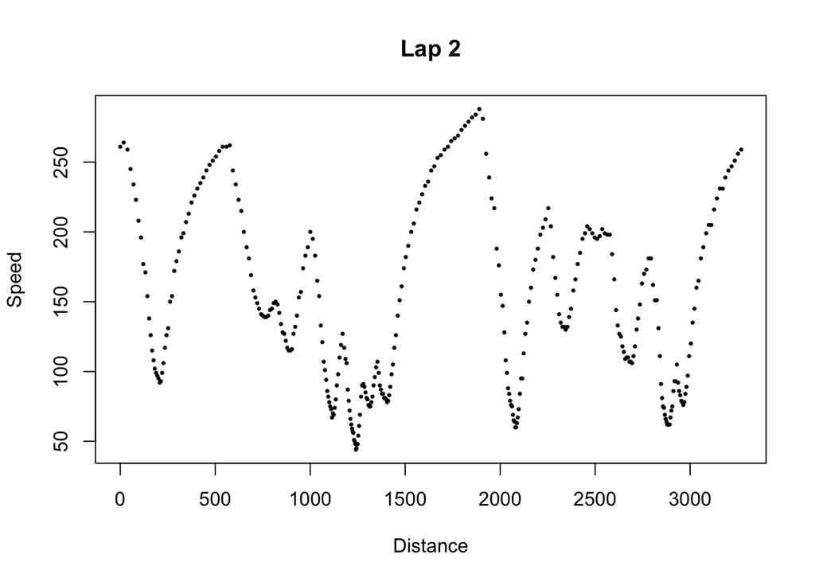

```r
lap2 <- ALO %>% filter(lap==2)
plot(lap2$Distance,lap2$Speed,pch=20,cex=0.5,xlab="Distance",ylab="Speed",main="Lap 2")
```

## 2.2 Visualization of speed curves for all laps

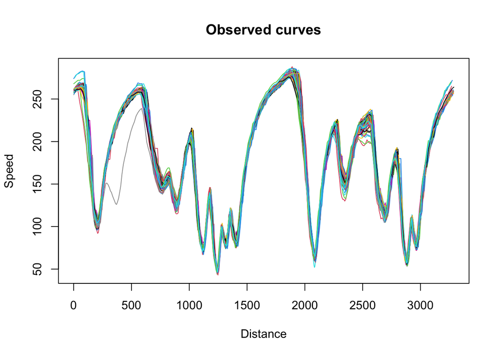

```r
xrange = range(ALO$Distance)
yrange = range(ALO$Speed)
plot(seq(xrange[1],xrange[2],length=50),seq(yrange[1],yrange[2],length=50),type="n",main="Observed curves",xlim=xrange,ylim=yrange,xlab="Distance",ylab="Speed")
for (i in unique(ALO$lap)){
  datap = ALO[which(ALO$lap==i),]
  lines(datap$Distance,datap$Speed,col=i)
}
```

The speed representations for each turn appear to be regular and non-periodic. We have therefore decided not to study the Fourier and wavelet bases. In the following, we shall concentrate on cubic spline bases.

# 3 Choosing nodes for the cubic spline base

## 3.1 First base

On the curve representation above, we can see that there are 24 “abrupt” changes (peaks) between acceleration and deceleration. We therefore decided to choose our nodes “by hand”. The 24 nodes chosen represent the distances of the entrances and exits of these bends (relative to the starting line).

```r
knots <- c(75,220,575,780,835,900,1020,1115,1180,1245,1290,1325,1360,1415,1900,2090,2260,2355,2565,2705,2785,2880,2930,2975)
```

```r
knots <- c(xrange[1],knots,xrange[2])
```

Here we have a 4th-order spline basis with 24 interior nodes and therefore 28 basis functions :

```r
bspbasis = create.bspline.basis(xrange,norder=4,breaks=knots)
```

- **Projection of individual curves onto the selected spline base :**

```r
laps = unique(ALO$lap)
nb_laps = length(laps)
CoeffMat = matrix(0,nrow=nb_laps,ncol=bspbasis$nbasis)
for (i in 1:nb_laps){
  decomp = Data2fd(ALO$Distance[ALO$lap==laps[i]],ALO$Speed[ALO$lap==laps[i]],basisobj = bspbasis)
  CoeffMat[i,] = as.vector(decomp$coefs)
}
head(CoeffMat)
```

```
##          [,1]     [,2]     [,3]     [,4]     [,5]      [,6]     [,7]     [,8]
## [1,] 249.4464 329.2739 133.0935 85.56907 402.9495  96.49027 161.4706 72.05380
## [2,] 241.8686 346.3732 134.5251 88.41474 399.1156 109.64074 159.7720 83.59400
## [3,] 148.9952 380.4808 144.0943 82.03570 400.7732 100.91267 162.2687 75.64593
## [4,] 212.3866 360.7799 151.0482 82.75027 400.3937 103.49681 158.9545 77.24844
## [5,] 230.8997 349.6562 158.6731 82.33900 398.6708 108.98015 160.5046 84.30591
## [6,] 192.7531 361.2370 158.4142 81.80166 404.8370 112.20452 158.6068 81.74960
##          [,9]      [,10]    [,11]       [,12]    [,13]    [,14]    [,15]
## [1,] 291.9376 -0.5914849 169.3460 -2.18201696 109.9191 78.42846 82.15088
## [2,] 290.2612 -0.9991253 174.2381  0.02185931 112.3124 80.71636 88.16135
## [3,] 289.1854 -5.6396762 177.9938 -1.85449445 110.9173 77.90655 89.28481
## [4,] 293.6899 -4.5641840 185.4453 -8.82971619 119.3539 77.70835 92.27863
## [5,] 290.0611 -0.9729180 178.8423 -5.18072192 121.0063 77.31326 89.50983
## [6,] 291.0734 -1.0318486 181.0933 -5.08732413 117.7785 76.50881 91.64160
##         [,16]    [,17]     [,18]    [,19]    [,20]    [,21]    [,22]    [,23]
## [1,] 159.8242 475.8930 -18.33004 261.2234 72.10967 323.3761 16.82985 263.6750
## [2,] 156.9318 477.7771 -20.96782 268.9931 77.37146 322.8672 21.01838 253.0340
## [3,] 149.3189 481.8406 -10.32344 256.6620 86.16271 331.8148 15.13709 270.0005
## [4,] 149.3264 490.2594 -15.29737 258.2452 86.05361 326.3855 21.05396 257.4330
## [5,] 163.2045 471.4013 -13.94253 269.6682 87.99255 331.8714 22.41257 260.1666
## [6,] 147.2648 483.2113 -10.84651 260.5365 95.18182 327.1103 31.69031 251.7197
##         [,24]    [,25]    [,26]    [,27]    [,28]
## [1,] 24.91328 82.83943 141.5979 311.3169 233.3012
## [2,] 31.44112 80.10483 132.0638 304.7344 241.4852
## [3,] 41.10768 80.11761 130.1162 302.6818 235.8910
## [4,] 39.50774 77.49367 138.5440 307.0326 233.8692
## [5,] 33.08187 79.65240 146.1441 303.3999 236.2998
## [6,] 25.06016 84.14245 144.8551 308.6503 232.1546
```

- **Visualization of smoothed curves :**

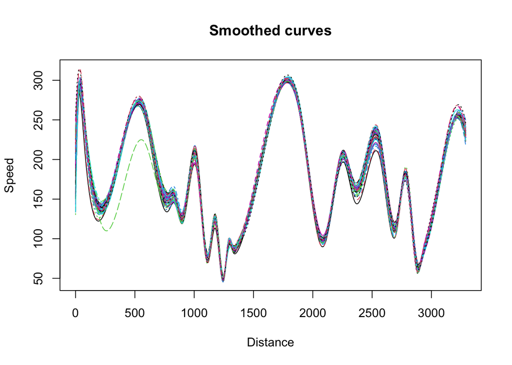

```r
alo.smooth = fd(t(CoeffMat),bspbasis)
plot(alo.smooth,xlab="Distance",ylab="Speed",main="Smoothed curves")
```

## 3.2 Second base

**Visualization of smoothed curves :**

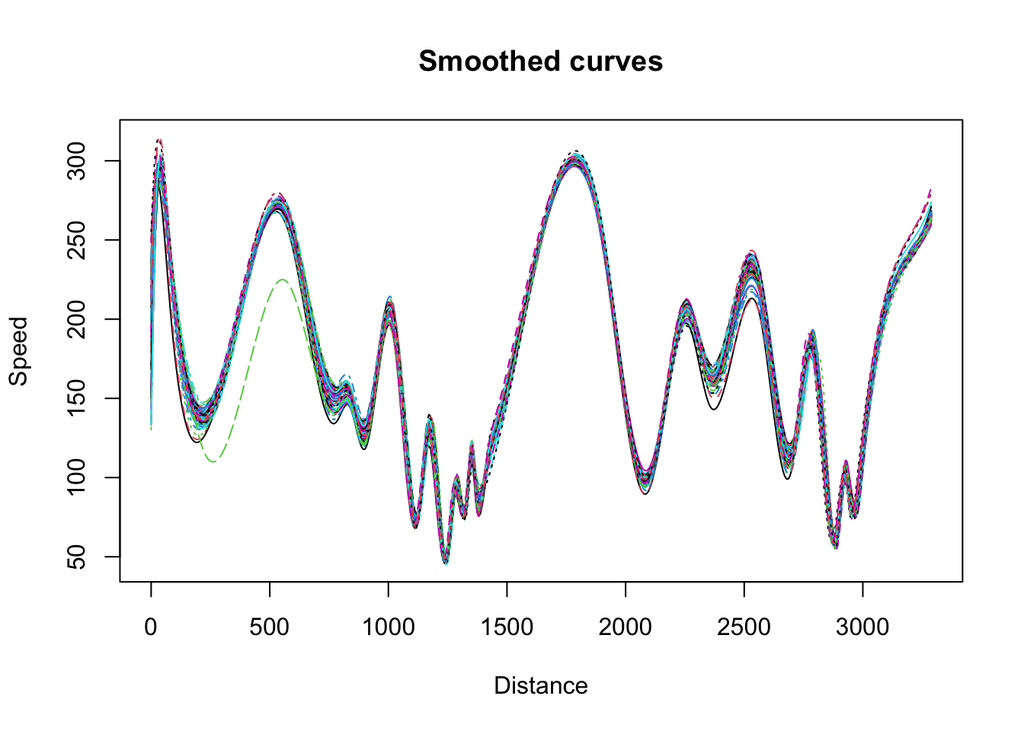

```r
knots <- sort(c(knots,seq(1100,1450,length=5),seq(2775,3000,length=5)))

bspbasis = create.bspline.basis(xrange,norder=4,breaks=knots)

CoeffMat = matrix(0,nrow=nb_laps,ncol=bspbasis$nbasis)
for (i in 1:nb_laps){
  decomp = Data2fd(ALO$Distance[ALO$lap==laps[i]],ALO$Speed[ALO$lap==laps[i]],basisobj = bspbasis)
  CoeffMat[i,] = as.vector(decomp$coefs)
}
alo.smooth = fd(t(CoeffMat),bspbasis)
plot(alo.smooth,xlab="Distance",ylab="Speed",main="Smoothed curves")
```

We find these representations very satisfactory. We shall therefore retain the spline base created above for the remainder of this section.

# 4 Exploratory statistics

## 4.1 Study of functional mean and standard deviation

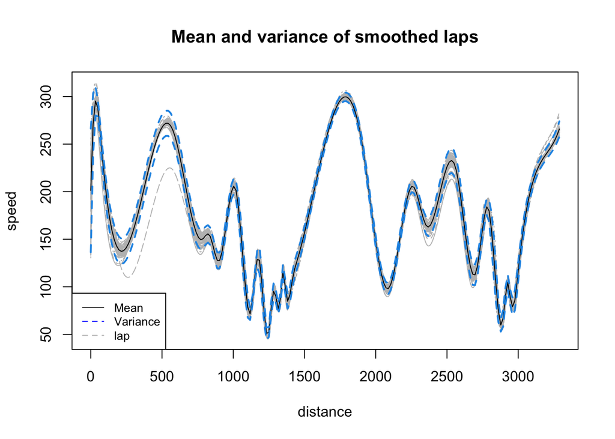

```r
fhat <- eval.fd(seq(xrange[1],xrange[2],length.out=325),alo.smooth)
mean_lap <- mean.fd(alo.smooth)
sd_lap <- sd.fd(alo.smooth)
plot(alo.smooth,col="gray",xlab="distance",ylab="speed", main = "Mean and variance of smoothed laps")
lines(mean_lap)
lines(mean_lap+2*sd_lap,lwd=2,col=4,lty=2)
lines(mean_lap-2*sd_lap,lwd=2,col=4,lty=2)
legend("bottomleft",legend = c("Mean", "Variance", "lap"), col=c("black", "blue", "gray"), lty=c(1,2,2), cex=0.8)
```

## 4.2 Functional PCA

```r
ACPF = pca.fd(alo.smooth,nharm=2,centerfns = TRUE)
ACPF$varprop
```

```
## [1] 0.3705133 0.1664614
```

```r
cumsum(ACPF$varprop)
```

```
## [1] 0.3705133 0.5369747
```

Here, the first two principal components explain 54% of the data.

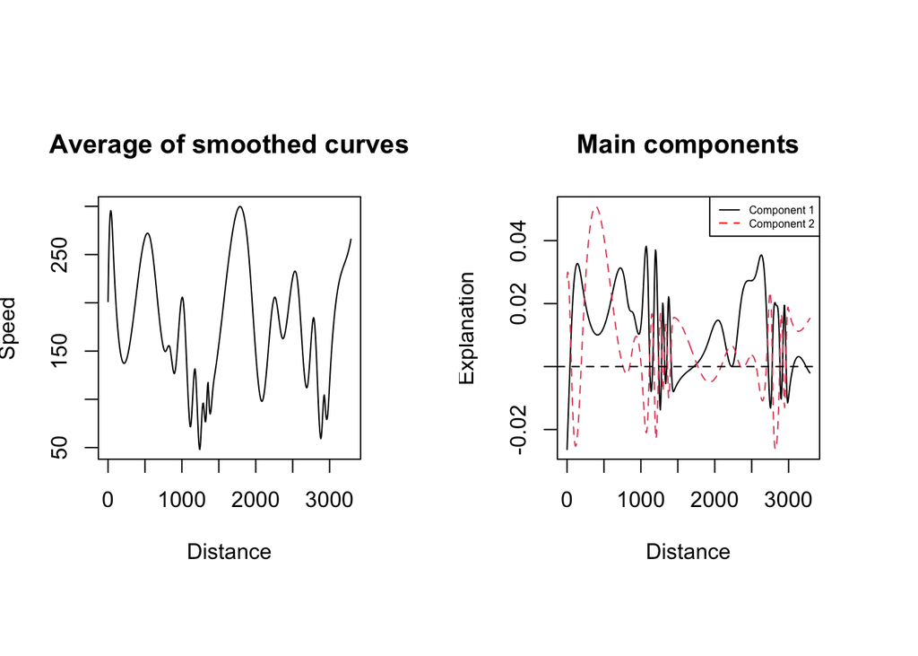

```r
par(mfrow=c(1,2), pin = c(2, 2))
plot(mean_lap, main ="Average of smoothed curves", ylab="Speed", xlab="Distance")
plot(ACPF$harmonics, main="Main components", ylab="Explanation", xlab="Distance")
legend("topright", legend = c("Component 1", "Component 2"), col=c("black", "red"), lty=1:2, cex=0.5)
```

The graph on the right shows the representations of the principal components of the PCA performed. The black curve is the one that captures the most information on the data. This same curve separates the data according to the first kilometer and the sector around 2.5km.

```r
head(ACPF$scores)
```

```
##           [,1]       [,2]
## [1,] -574.5493  64.457571
## [2,] -430.4633  42.499948
## [3,] -335.6875 -93.061531
## [4,] -360.7013  -2.790562
## [5,] -299.0054  44.124505
## [6,] -219.3278  52.304805
```

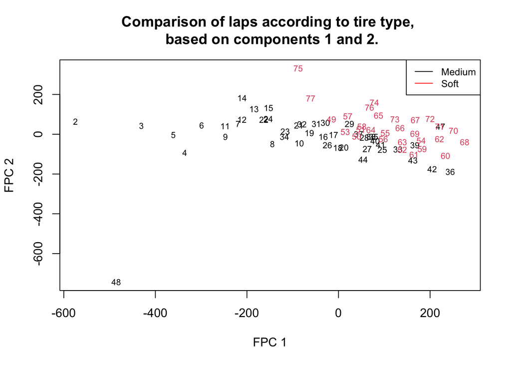

```r
plot(ACPF$scores[,1],ACPF$scores[,2],pch=3,xlab="FPC 1", ylab="FPC 2",type="n", main = "Comparison of laps according to tire type, \n based on components 1 and 2.")
nomstours <- unique(ALO$lap)
type_pneu <- as.factor(laps_alonso$Compound)
text(ACPF$scores[,1],ACPF$scores[,2],labels=nomstours,cex=0.7,col=as.numeric(type_pneu))
legend("topright", legend = c("Medium", "Soft"), col=c("black", "red"), lty=c(1,1), cex=0.8)
```

This graph shows that axis 2 separates lap 48 from the other laps. Let’s take a look at which turn it was.

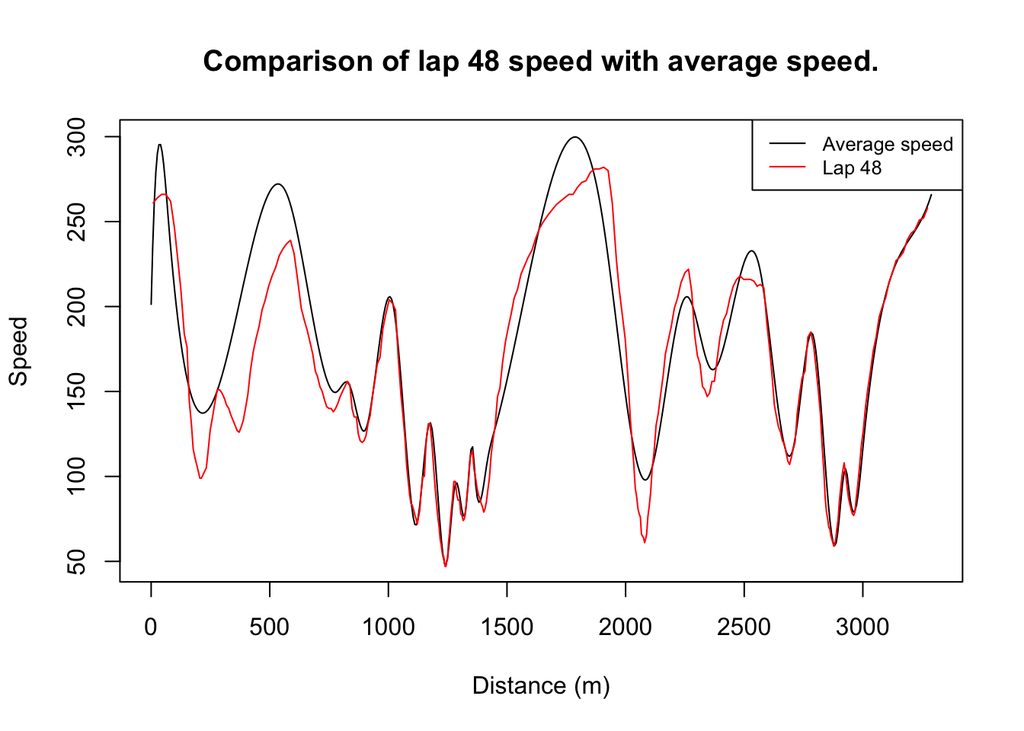

```r
plot(mean_lap, xlab = "Distance (m)", ylab="Speed", main = "Comparison of lap 48 speed with average speed.")
lines(ALO[ALO$lap==48,]$Distance,ALO[ALO$lap==48,]$Speed, col="red")
legend("topright", legend = c("Average speed", "Lap 48"), col=c("black", "red"), lty=c(1,1), cex=0.8)
```

Indeed, on this lap, Ferando Alonso braked abnormally at the start of the lap (400m). Moreover, the peak of the second main axis corresponds to this distance of around 400m.

It’s this braking that makes this lap different from the others.

If we return to the projection of laps on the axes, we can see that axis 1 separates laps on medium tires (black) from those on soft tires (red).

If we go back to the representation of the variance and the analysis that was carried out, we can then think that the type of tire will have an influence on braking and acceleration. To try and confirm this hypothesis, we look at which types of tire are used when braking at 2.5km.

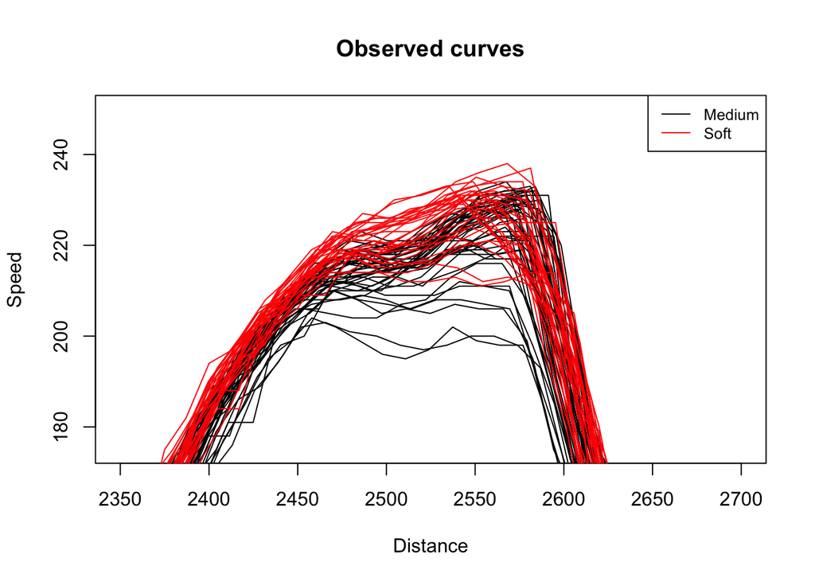

```r
for(i in 1:nrow(laps_alonso))
if(laps_alonso$Compound[i]=="MEDIUM"){
  laps_alonso$color[i]="black"
} else if(laps_alonso$Compound[i]=="SOFT"){
  laps_alonso$color[i]="red"
}

plot(seq(xrange[1],xrange[2],length=50),seq(yrange[1],yrange[2],length=50),type="n",main="Observed curves",xlab="Distance",ylab="Speed", xlim=c(2350, 2700),ylim=c(175,250))

legend("topright", legend = c("Medium", "Soft"), col=c("black", "red"), lty=c(1,1), cex=0.8)

for (i in unique(ALO$lap)){
  datap = ALO[which(ALO$lap==i),]
  lines(datap$Distance,datap$Speed,col=laps_alonso$color[which(laps_alonso$LapNumber==i)])
}
```

This graph shows that pre-braking speed is generally lower for laps on medium tires than on soft tires. This confirms our hypothesis.

# 5 Conclusion

From what we’ve been able to observe, the braking moments at 250m, 800m and 2.5km are surely the places on the circuit where Ferando Alonso can gain (or lose) the most time on his lap. The type of tire will also influence his braking at these points.